# Clustering Analysis on the Covid-19 Alignment Hit Table

Group 3 - CORONAVIRUS

6/17/2020

## Data Preprocessing and Exploration

First, read table from the CSV file.

```r
corona <- read.table('MN997409.1-4NY0T82X016-Alignment-HitTable.csv', header = TRUE, sep=',')
summary(corona)
```

```
##    X.query.acc.ver.  X.subject.acc.ver.  X.identity.     X.alignment.length.
##  MN997409.1:263     AP006561.1:  4      Min.   : 77.56   Min.   : 1603
##                     AY278554.2:  4      1st Qu.: 80.05   1st Qu.: 1925
##                     AY282752.2:  4      Median : 82.30   Median : 5417
##                     AY283796.1:  4      Mean   : 86.06   Mean   :10711
##                     AY291451.1:  4      3rd Qu.: 90.19   3rd Qu.:17716
##                     AY304486.1:  4      Max.   :100.00   Max.   :29882
##                     (Other)   :239
##  X.mismatches.     X.gap.opens.     X.q..start.      X.q..end.
##  Min.   :   0.0   Min.   :  0.00   Min.   :    1   Min.   : 1923
##  1st Qu.: 142.0   1st Qu.: 12.00   1st Qu.:   16   1st Qu.:21577
##  Median : 359.0   Median : 35.00   Median : 3956   Median :27910
##  Mean   : 919.2   Mean   : 57.82   Mean   :11296   Mean   :21971
##  3rd Qu.: 989.0   3rd Qu.: 68.00   3rd Qu.:22539   3rd Qu.:29876
##  Max.   :2952.0   Max.   :172.00   Max.   :28257   Max.   :29882
##
##   X.s..start.      X.s..end.       X.evalue.  X.bit.score.
##  Min.   :    1   Min.   : 1672   Min.   :0   Min.   : 1011
##  1st Qu.:    1   1st Qu.:21489   1st Qu.:0   1st Qu.: 2101
##  Median : 3875   Median :27783   Median :0   Median : 3936
##  Mean   :11213   Mean   :21889   Mean   :0   Mean   :14240
##  3rd Qu.:22429   3rd Qu.:29729   3rd Qu.:0   3rd Qu.:15175
##  Max.   :28137   Max.   :30256   Max.   :0   Max.   :55182
##
```

Print the structure of the dataset.

```
## 'data.frame':    263 obs. of  12 variables:
##  $ X.query.acc.ver.   : Factor w/ 1 level "MN997409.1": 1 1 1 1 1 1 1 1 1 1 ...
##  $ X.subject.acc.ver. : Factor w/ 100 levels "AP006561.1","AY278554.2",..: 78 87 86 67 66 56 97 83 74 100 ...
##  $ X.identity.        : num  100 100 100 100 100 ...
##  $ X.alignment.length.: int  29882 29882 29882 29882 29882 29878 29882 29882 29882 29882 ...
##  $ X.mismatches.      : int  0 3 3 3 3 2 4 4 4 4 ...
##  $ X.gap.opens.       : int  0 0 0 0 0 0 0 0 0 0 ...
##  $ X.q..start.        : int  1 1 1 1 1 4 1 1 1 1 ...
##  $ X.q..end.          : int  29882 29882 29882 29882 29882 29881 29882 29882 29882 29882 ...
##  $ X.s..start.        : int  1 1 1 1 1 1 1 1 1 1 ...
##  $ X.s..end.          : int  29882 29882 29882 29882 29882 29878 29882 29882 29882 29882 ...
##  $ X.evalue.          : int  0 0 0 0 0 0 0 0 0 0 ...
##  $ X.bit.score.       : int  55182 55166 55166 55166 55166 55164 55160 55160 55160 55160 ...
```

Inspect the correlation between attributes.

```r
corona1 <- corona[, -c(1,2)]
m <- cor(corona1)
m
```

```
##                     X.identity. X.alignment.length. X.mismatches. X.gap.opens.
## X.identity.          1.00000000           0.6315241   -0.45350912  -0.53518273
## X.alignment.length.  0.63152406           1.0000000    0.20668048   0.13670210
## X.mismatches.       -0.45350912           0.2066805    1.00000000   0.98817960
## X.gap.opens.        -0.53518273           0.1367021    0.98817960   1.00000000
## X.q..start.         -0.05251914          -0.5607197   -0.19730598  -0.18321120
## X.q..end.            0.56679360           0.3555704   -0.02137023  -0.07469492
## X.s..start.         -0.05186980          -0.5607610   -0.19895627  -0.18478193
## X.s..end.            0.56965267           0.3595212   -0.02230165  -0.07578202
## X.evalue.                    NA                  NA            NA           NA
## X.bit.score.         0.79343760           0.9446388   -0.12576612  -0.19322563
##                     X.q..start.   X.q..end. X.s..start.   X.s..end. X.evalue.
## X.identity.         -0.05251914  0.56679360  -0.0518698  0.56965267        NA
## X.alignment.length. -0.56071966  0.35557037  -0.5607610  0.35952123        NA
## X.mismatches.       -0.19730598 -0.02137023  -0.1989563 -0.02230165        NA
## X.gap.opens.        -0.18321120 -0.07469492  -0.1847819 -0.07578202        NA
## X.q..start.          1.00000000  0.57451565   0.9999868  0.57102821        NA
## X.q..end.            0.57451565  1.00000000   0.5744648  0.99997449        NA
## X.s..start.          0.99998684  0.57446475   1.0000000  0.57100661        NA
## X.s..end.            0.57102821  0.99997449   0.5710066  1.00000000        NA
## X.evalue.                    NA          NA          NA          NA         1
## X.bit.score.        -0.50268918  0.36734345  -0.5021808  0.37165974        NA
##                     X.bit.score.
## X.identity.            0.7934376
## X.alignment.length.    0.9446388
## X.mismatches.         -0.1257661
## X.gap.opens.          -0.1932256
## X.q..start.           -0.5026892
## X.q..end.              0.3673434
## X.s..start.           -0.5021808
## X.s..end.              0.3716597
## X.evalue.                     NA
## X.bit.score.           1.0000000
```

Import libraries used for plotting.

```r
library(ggplot2)
library(tidyr)
```

Plot histograms to show the distributions for each attribute.

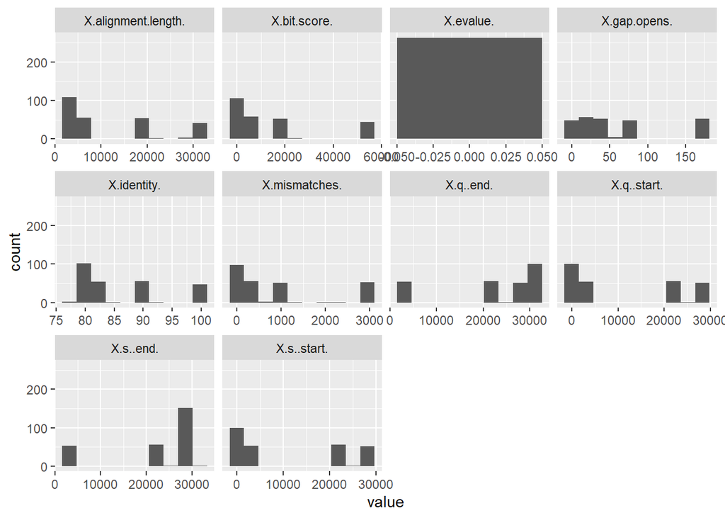

Plot scatter matrix between all pairs of two attributes in the dataset.

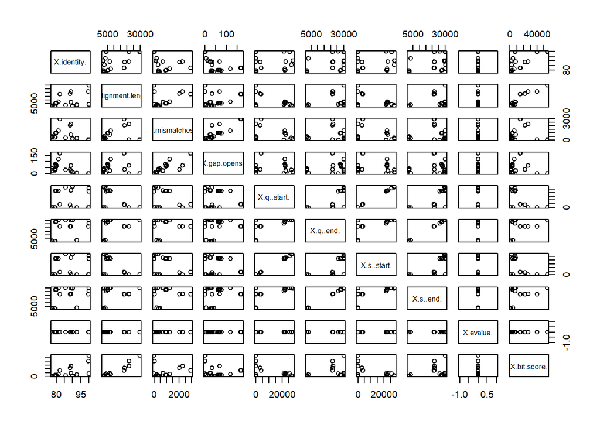

Import “car” library as we will use the function `scatterplot()` to generate scatter plots for highly correlated attributes.

```r
library("car")
```

Plot individual scatter plots for pairs of attributes with high correlations. The selected pairs of features are:

- `X.mismatches.` and `X.gap.opens.`
- `X.s..start.` and `X.q..start.`
- `X.s..end.` and `X.q..end.`
- `X.alignment.length.` and `X.bit.score.`

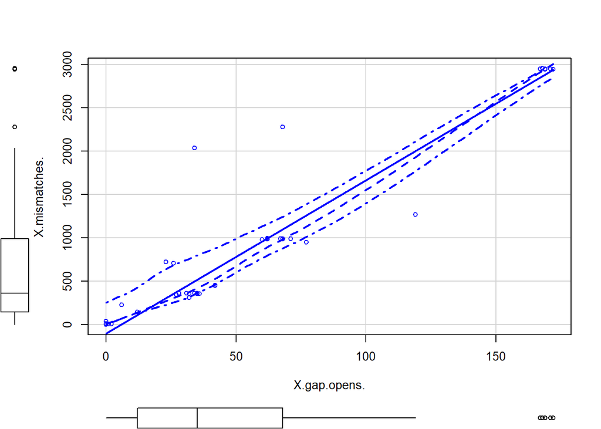

```r
scatterplot(X.mismatches. ~ X.gap.opens., data = corona)
```

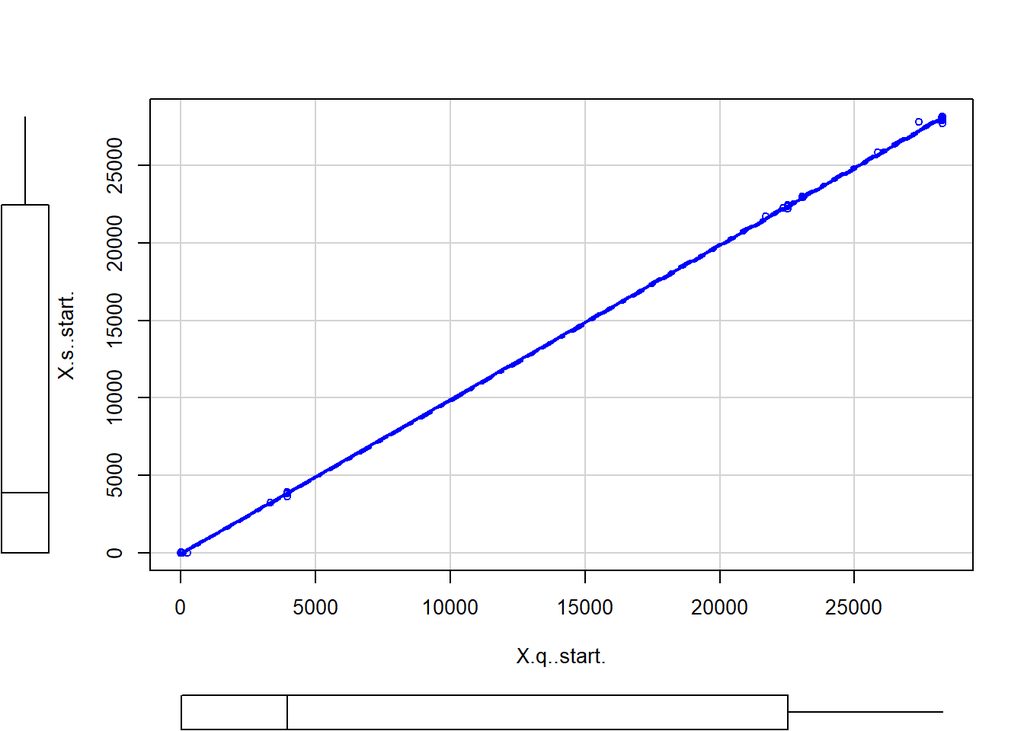

```r
scatterplot(X.s..start. ~ X.q..start., data = corona)
```

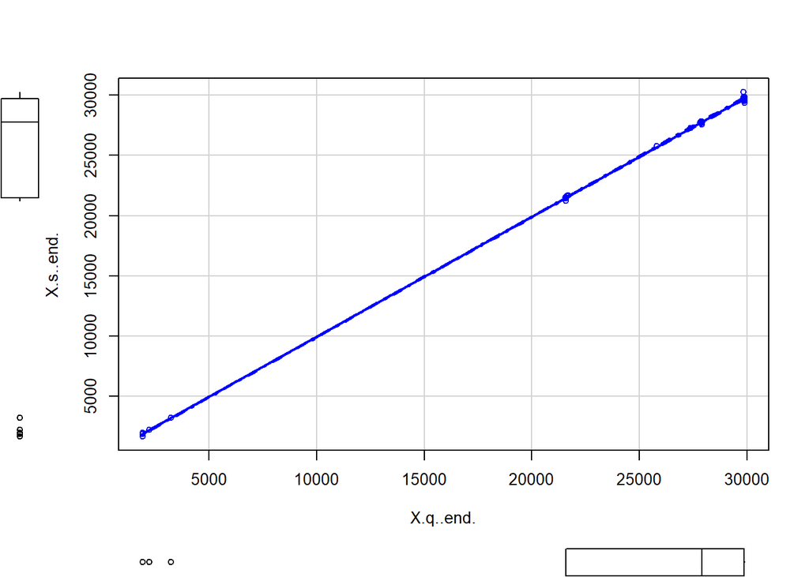

```r
scatterplot(X.s..end. ~ X.q..end., data = corona)
```

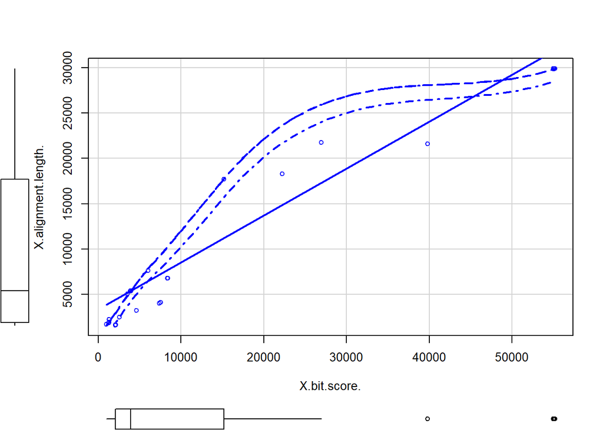

```r
scatterplot(X.alignment.length. ~ X.bit.score., data = corona)
```

Next, inspect the data by calculating the lower and upper bounds of each attribute using IQR rule.

```r
# Generate lower and upper bounds using IQR rule
# Calculate quartile 1 and 3 for all columns
coronaQuantiles <- sapply(corona1, quantile, na.rm = TRUE)
coronaQ1 <- coronaQuantiles[2,]
coronaQ3 <- coronaQuantiles[4,]

# Calculate lower and upper bounds to detect outlier for all columns
coronaIQR <- sapply(corona1, IQR, na.rm = TRUE)
coronaS = 1.5 * coronaIQR
coronaLB = coronaQ1 - coronaS
coronaUB = coronaQ3 + coronaS

# Show lower and upper bounds for all columns
corona.bounds <- data.frame(lower.bound = coronaLB,
                            upper.bound = coronaUB)
corona.bounds
```

```
##                     lower.bound upper.bound
## X.identity.             64.8365    105.4005
## X.alignment.length. -21761.5000  41402.5000
## X.mismatches.        -1128.5000   2259.5000
## X.gap.opens.           -72.0000    152.0000
## X.q..start.         -33768.5000  56323.5000
## X.q..end.             9129.2500  42323.2500
## X.s..start.         -33641.0000  56071.0000
## X.s..end.             9129.0000  42089.0000
## X.evalue.                0.0000      0.0000
## X.bit.score.        -17510.0000  34786.0000
```

Display the columns with outlier values below the lower bound according to the IQR rule.

```r
# Print columns and number of outliers below the lower bound (IQR rule).
coronaMin <- coronaQuantiles[1,]

for (i in 1:length(coronaLB)) {
    if (coronaLB[[i]] > coronaMin[[i]]) {
        col_name <- names(coronaLB)[i]
        col_LB <- coronaLB[[i]]

        corona1belowLB <- corona1[which(corona1[col_name] < col_LB),][col_name]
        print(paste0(col_name, ": ", nrow(corona1belowLB), " of ", nrow(corona1), " records"))
    }
}
```

```
## [1] "X.q..end.: 54 of 263 records"
## [1] "X.s..end.: 54 of 263 records"
```

Display the columns with outlier values above the upper bound according to the IQR rule.

```r
# Print columns and number of outliers above the upper bound (IQR rule).
coronaMax <- coronaQuantiles[5,]

for (i in 1:length(coronaUB)) {
    if (coronaUB[[i]] < coronaMax[[i]]) {
        col_name <- names(coronaUB)[i]
        col_UB <- coronaUB[[i]]

        corona1aboveLB <- corona1[which(corona1[col_name] > col_UB),][col_name]
        print(paste0(col_name, ": ", nrow(corona1aboveLB), " of ", nrow(corona1), " records"))
    }
}
```

```
## [1] "X.mismatches.: 54 of 263 records"
## [1] "X.gap.opens.: 53 of 263 records"
## [1] "X.bit.score.: 45 of 263 records"
```

## Hierarchical Clustering

### Data Preparation for Hierarchical Clustering

```r
# Remove "X.query.acc.ver." and "X.evalue."
corona.hclust <- corona[-c(1, 11)]

# Define attributes used for hierarchical clustering
vars.to.use <- colnames(corona.hclust)[-1]   # 9 attributes

# Transform data frame into a scaled matrix
corona_scale <- scale(corona.hclust[,vars.to.use])

# Create distance matrix
d_euclidean <- dist(corona_scale, method = "euclidean")
```

### Perform Hierarchical Clustering + Dendrogram

Define helper functions as follows:

**Helper function #1**: Print selected attributes of the samples in each cluster

```r
print_clusters <- function(labels, k) {
  for(i in 1:k) {
    print(paste("cluster", i))
    print(corona[labels==i, c("X.subject.acc.ver.",
                              "X.bit.score.",
                              "X.alignment.length.",
                              "X.mismatches.",
                              "X.gap.opens.")])
  }
}
```

**Helper function #2**: Generate dendrogram, specifying $k$ is optional.

```r
plot_hclust <- function(pfitHClust, k = NA, label = FALSE) {
  plot(pfitHClust, labels = label)

  # If k is specified, draw rectangles to frame clusters in the dendrogram.
  if (is.na(k) == FALSE) {
    rect.hclust(pfitHClust, k = k)
  }
}
```

Now, plot dendrograms for different hierarchical clustering methods, here we use:

- “ward.D”
- “ward.D2”
- “complete”
- “average”

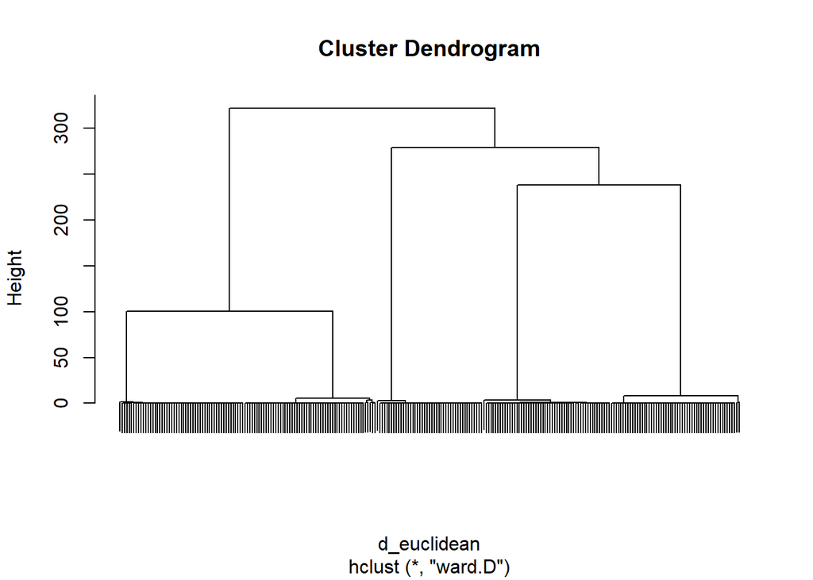

```r
plot_hclust(hclust(d_euclidean, method = "ward.D"))
```

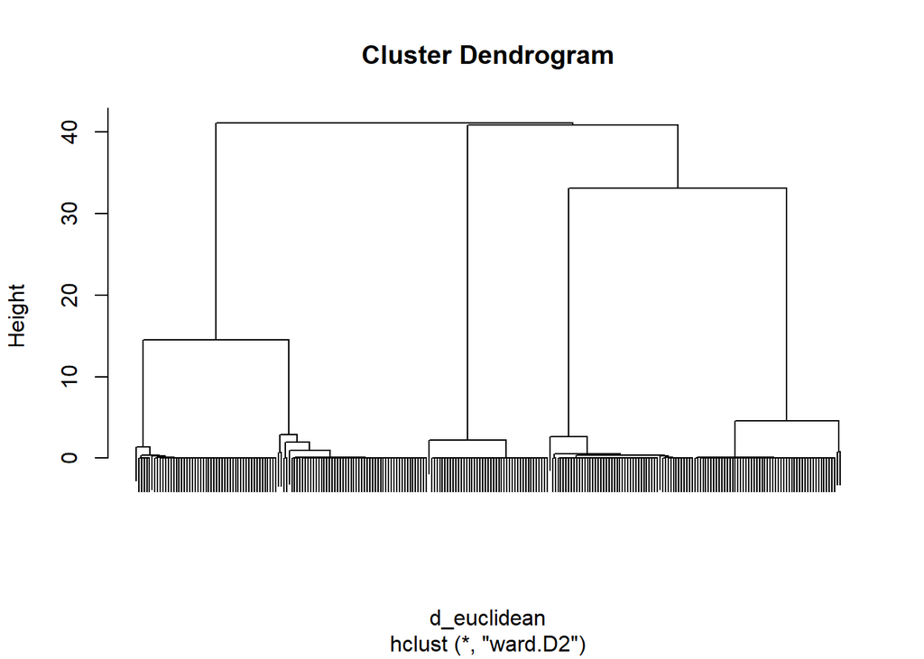

```r
plot_hclust(hclust(d_euclidean, method = "ward.D2"))
```

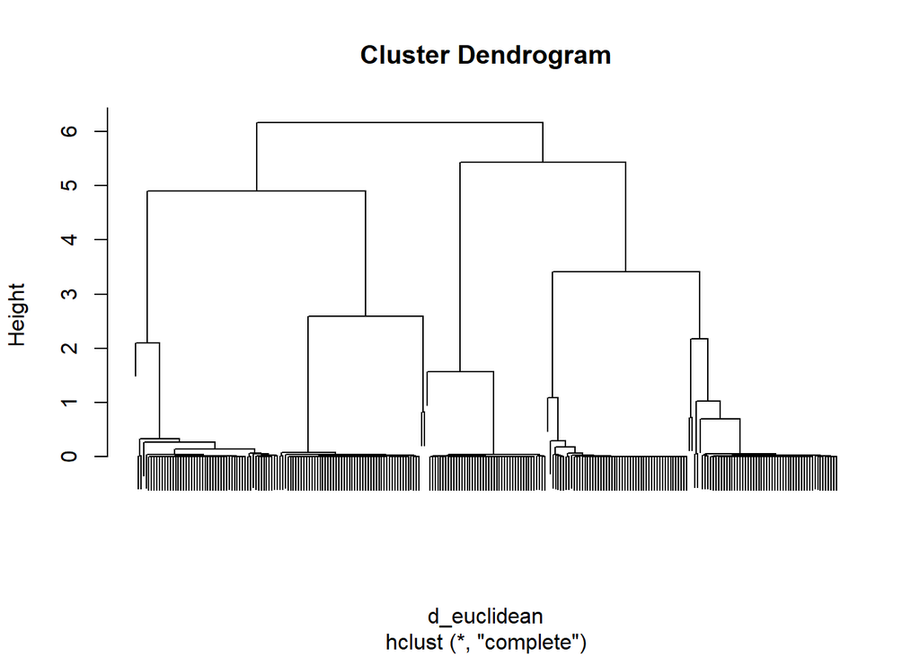

```r
plot_hclust(hclust(d_euclidean, method = "complete"))
```

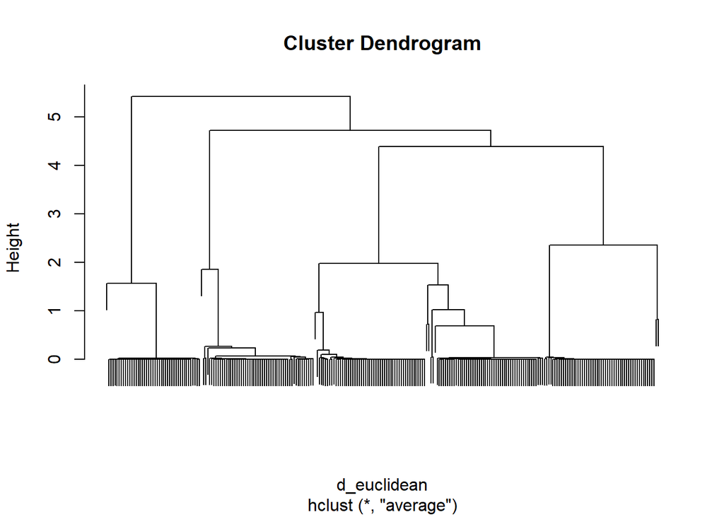

```r
plot_hclust(hclust(d_euclidean, method = "average"))
```

Plot dendrograms for “ward.D” by specifying the number of clusters, $k$ as 4 and 5 respectively.

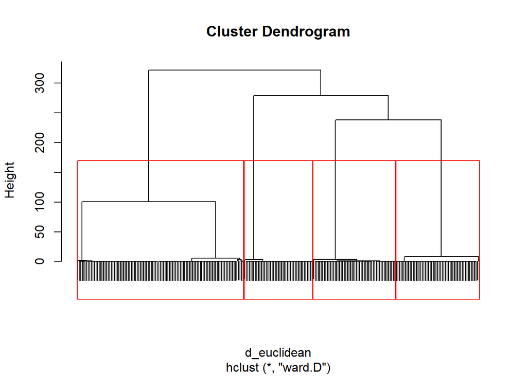

```r
plot_hclust(hclust(d_euclidean, method = "ward.D"), k = 4)
```

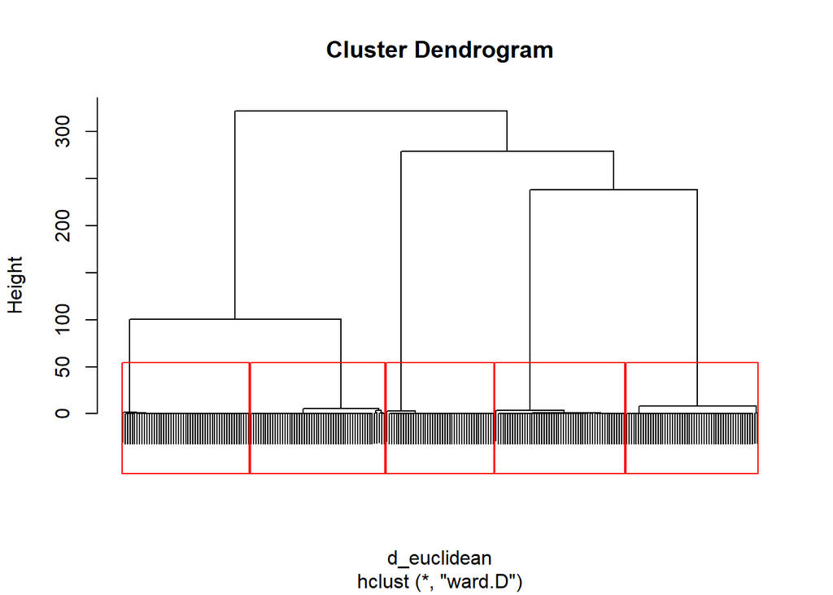

```r
plot_hclust(hclust(d_euclidean, method = "ward.D"), k = 5)
```

### Running `clusterboot` for Hierarchical Clustering

Import “fpc” library as we will use the `clusterboot()` function to examine cluster stability.

```r
library("fpc")
```

Set seed value.

```r
set.seed(123)
```

**Helper function #3**: Print selected results from `clusterboot`

```r
display.cboot.result <- function(cboot.result) {
  summary(cboot.result)

  groups <- cboot.result$result$partition
  print_clusters(groups, kbest.p)

  print("Vector of cluster stabilities")
  print(cboot.result$bootmean)

  print("How many times each cluster was dissolved?")
  print(cboot.result$bootbrd)
}
```

Running `clusterboots` for **4 clusters** using 4 different clustering methods respectively.

*Only showing results for “ward.D” because the output will become very long if the complete set of results is shown.*

```r
kbest.p <- 4

# Note: invisible(capture.output()) is used to suppress output
# ward.D
invisible(capture.output(cboot.hclust <- clusterboot(corona_scale,
                                                     clustermethod = hclustCBI,
                                                     method = "ward.D",
                                                     k = kbest.p) ))
display.cboot.result(cboot.hclust)
```

```
## [1] "cluster 1"
##    X.subject.acc.ver. X.bit.score. X.alignment.length. X.mismatches.
## 1          MN997409.1        55182               29882             0
## 2          MT020881.1        55166               29882             3
## 3          MT020880.1        55166               29882             3
## 4          MN985325.1        55166               29882             3
## 5          MN975262.1        55166               29882             3
## 6          LC522974.1        55164               29878             2
## 7          MT049951.1        55160               29882             4
## 8          MT019532.1        55160               29882             4
## 9          MN996528.1        55160               29882             4
## 10        NC_045512.2        55160               29882             4
## 11         MN908947.3        55160               29882             4
## 12         LC522975.1        55158               29878             3
## 13         LC522973.1        55158               29878             3
```

[output cut: 527 more lines]

Running `clusterboots` for **5 clusters** using 4 different clustering methods respectively.

```r
# 5 clusters
kbest.p <- 5

# ward.D
invisible(capture.output(cboot.hclust <- clusterboot(corona_scale,
                                                     clustermethod = hclustCBI,
                                                     method = "ward.D",
                                                     k = kbest.p) ))
display.cboot.result(cboot.hclust)
```

```
## [1] "cluster 1"
##    X.subject.acc.ver. X.bit.score. X.alignment.length. X.mismatches.
## 1          MN997409.1        55182               29882             0
## 2          MT020881.1        55166               29882             3
## 3          MT020880.1        55166               29882             3
## 4          MN985325.1        55166               29882             3
## 5          MN975262.1        55166               29882             3
## 6          LC522974.1        55164               29878             2
## 7          MT049951.1        55160               29882             4
## 8          MT019532.1        55160               29882             4
## 9          MN996528.1        55160               29882             4
## 10        NC_045512.2        55160               29882             4
## 11         MN908947.3        55160               29882             4
## 12         LC522975.1        55158               29878             3
## 13         LC522973.1        55158               29878             3
```

[output cut: 530 more lines]

### Optimal k

Plot CH and WSS criteria on the same graph to find the optimal $k$.

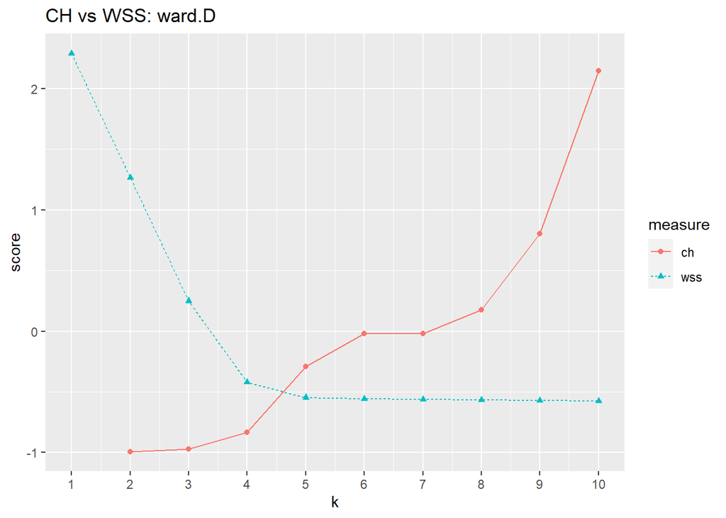

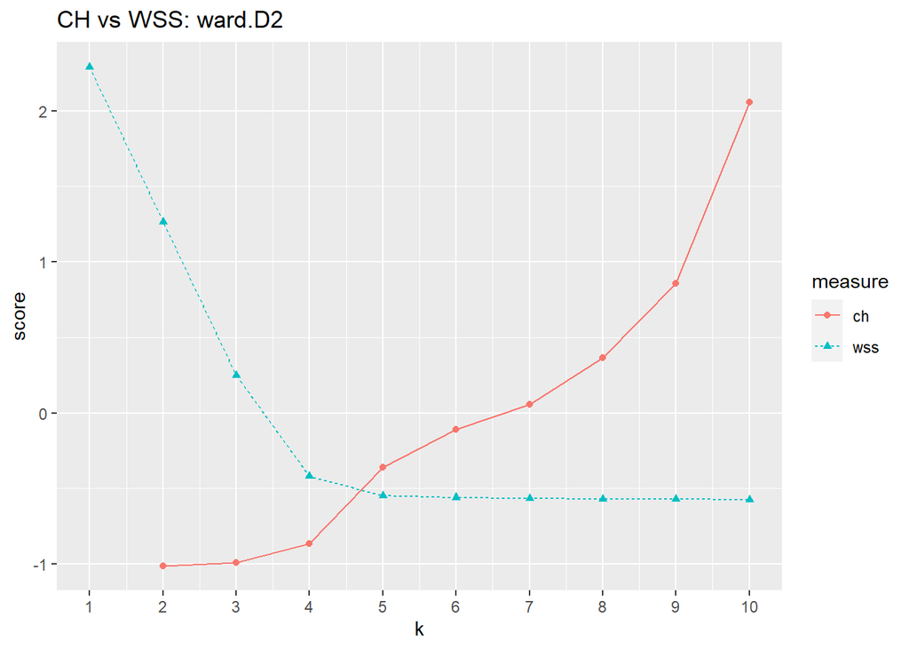

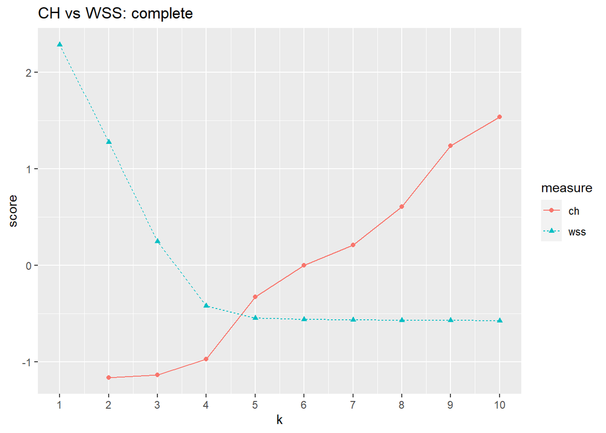

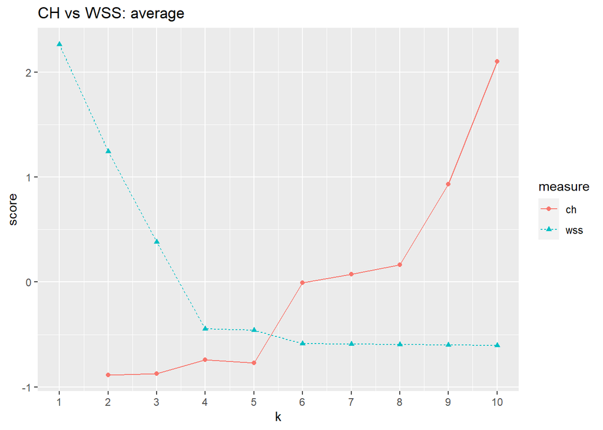

### Plot Distribution of Clusters using PCA

Visualize clusters for $k$ = 4.

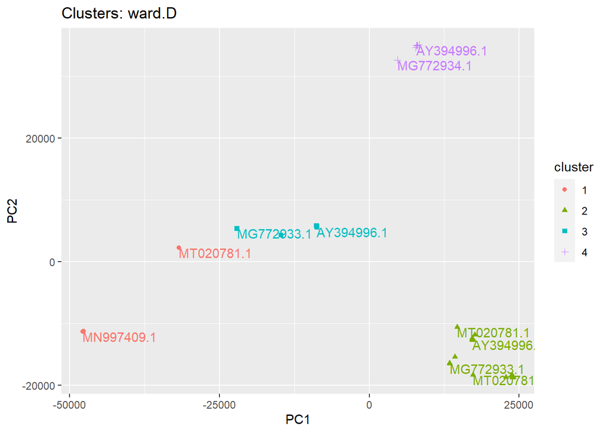

Visualize clusters for $k$ = 5.

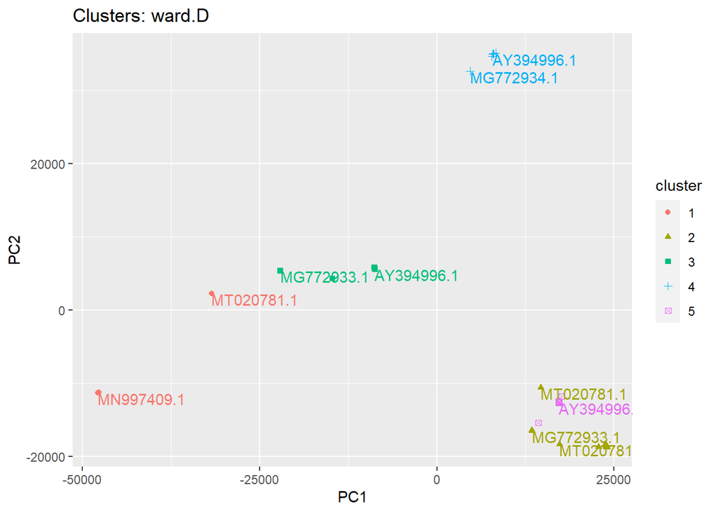

## K-Means Clustering

### View Optimal $k$

Generate principal components using PCA.

```r
## PCA Features Extraction
nComp <- 2
corona <- corona.hclust[, vars.to.use]
pca <- predict(prcomp(corona), newdata = corona)[,1:nComp]
```

Plot WSS criterion on the graph to identify the “elbow” - the optimal $k$.

WSS curve for the **unscaled** (i.e. the original) dataset.

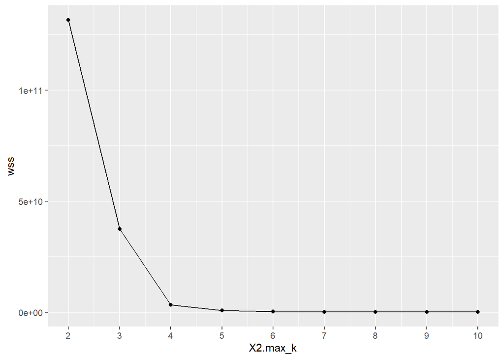

WSS curve for the **scaled** dataset.

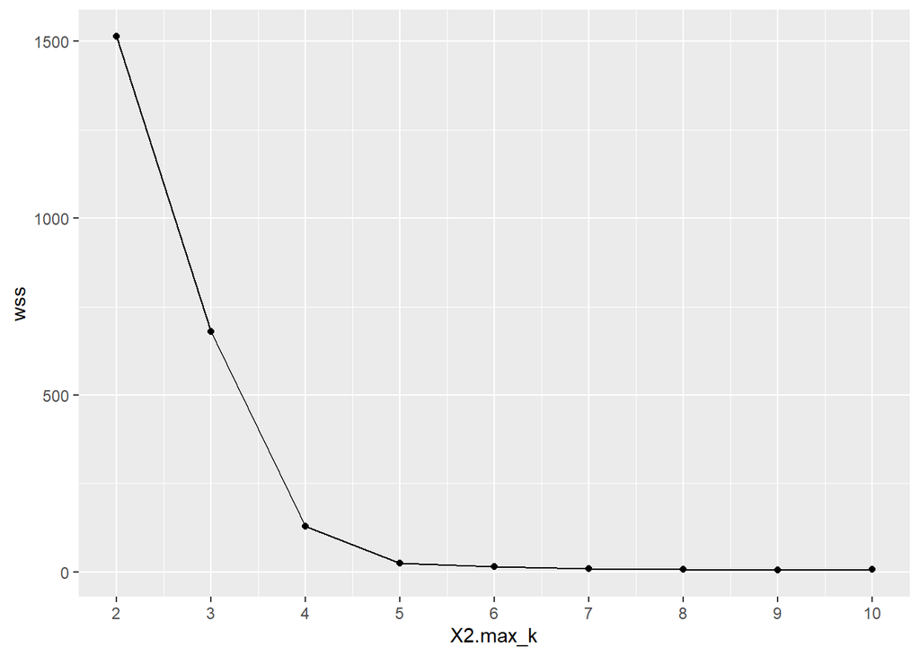

### Details of the K-means Clusters

Inspect details for the best k-means clusters, such as cluster labels, centroids and more.

```r
corona_cluster_1 <- kmeans(corona, 5)

# Cluster labels: which cluster does each sample is assigned to?
corona_cluster_1$cluster
```

```
##   [1] 4 4 4 4 4 4 4 4 4 4 4 4 4 4 4 4 4 4 4 4 4 4 4 4 4 4 4 4 4 4 4 4 4 4 4 4 4
##  [38] 4 4 4 4 4 4 4 4 2 2 5 2 5 2 3 5 2 2 1 5 2 2 1 5 2 2 1 5 2 2 1 5 2 2 1 5 2
##  [75] 2 1 5 2 2 1 5 2 2 1 5 2 2 1 5 2 2 1 5 2 2 1 5 2 2 1 5 2 2 1 5 2 2 1 5 2 1
## [112] 5 2 2 1 5 2 2 1 5 2 2 1 5 2 2 1 5 2 2 1 5 2 2 1 5 2 2 1 5 2 2 1 5 2 2 1 5
## [149] 2 2 1 5 2 2 1 5 2 2 1 5 2 2 1 5 2 2 1 5 2 2 1 5 2 2 1 5 2 2 1 5 2 2 1 5 2
## [186] 2 1 5 2 2 1 5 2 2 1 5 2 2 1 5 2 2 1 5 2 2 1 5 2 2 1 5 2 2 1 5 2 2 1 5 2 2
## [223] 1 5 2 2 1 5 2 2 1 5 2 2 1 5 2 2 1 5 2 2 1 5 2 2 1 5 2 2 1 5 2 2 1 5 2 2 1
## [260] 5 2 2 1
```

```r
# The average values of the centroids (centers) for each cluster.
corona_cluster_1$centers
```

```
##   X.identity. X.alignment.length. X.mismatches. X.gap.opens.  X.q..start.
## 1    79.20409            1933.642    362.056604   34.1509434    21.226415
## 2    85.37155            3635.945    564.807339   39.7064220 25287.972477
## 3    92.72600            3217.000    227.000000    6.0000000     6.000000
## 4    99.97533           29690.578      5.755556    0.1111111     5.377778
## 5    82.54822           17798.709   2918.545455  164.6909091  3872.781818
##   X.q..end.  X.s..start. X.s..end. X.bit.score.
## 1  1934.132     4.735849  1916.943     1305.396
## 2 28893.596 25141.550459 28750.936     3230.798
## 3  3219.000     6.000000  3218.000     4638.000
## 4 29694.956     1.022222 29689.244    54789.778
## 5 21578.964  3785.345455 21492.364    15521.655
```

```r
# How many samples in each cluster?
corona_cluster_1$size
```

```
## [1]  53 109   1  45  55
```

### Different Stages of K-means Clustering Algorithm

Plot different stages of the K-means clustering algorithm.

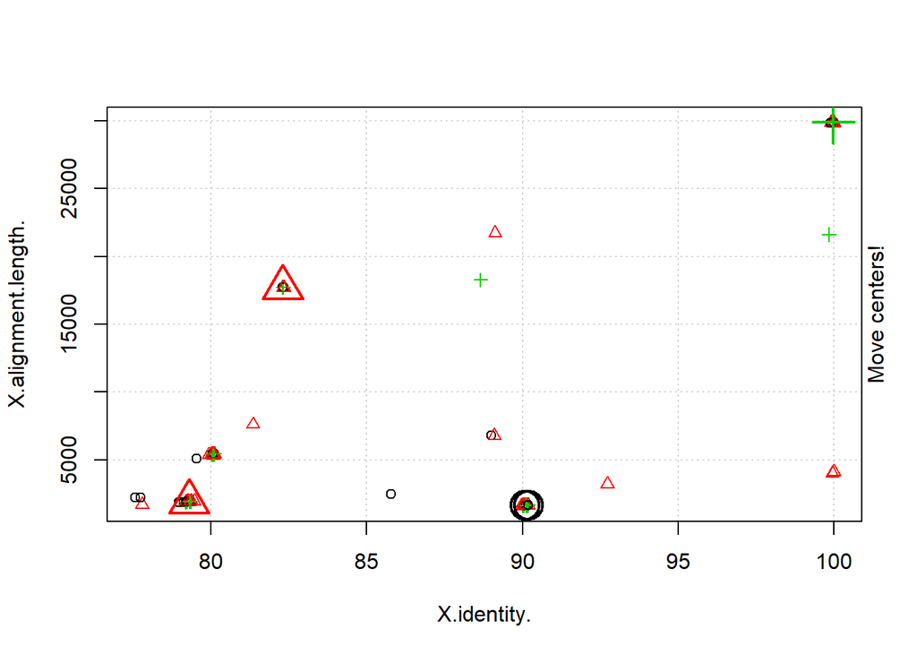

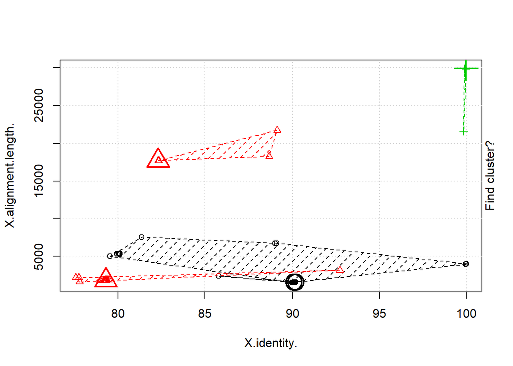

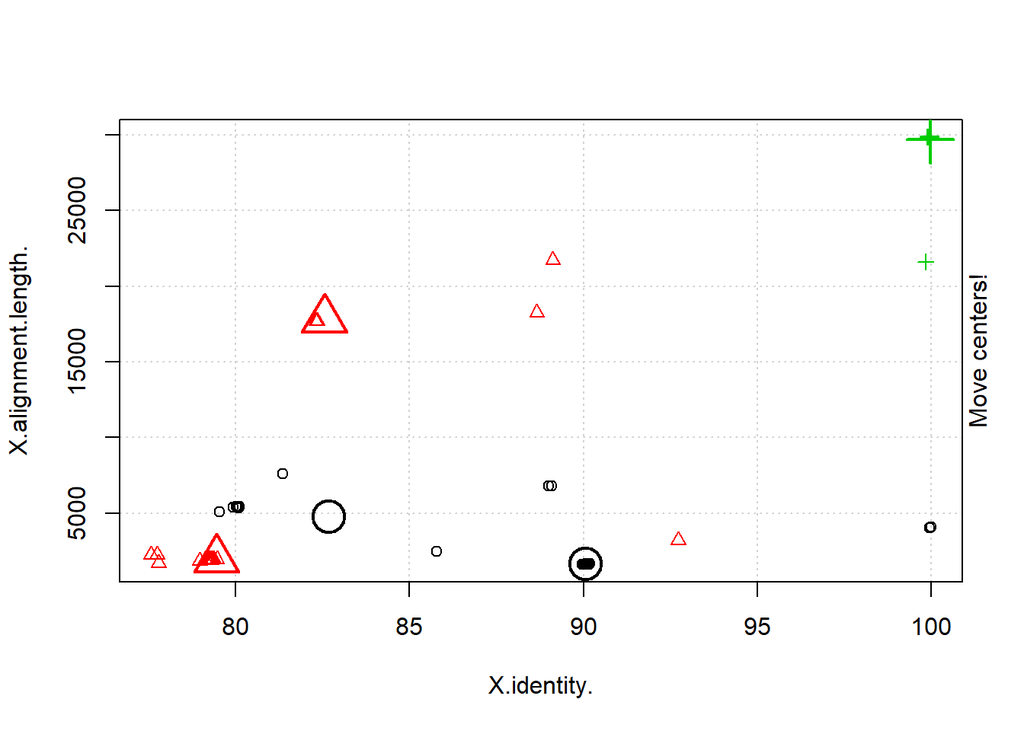

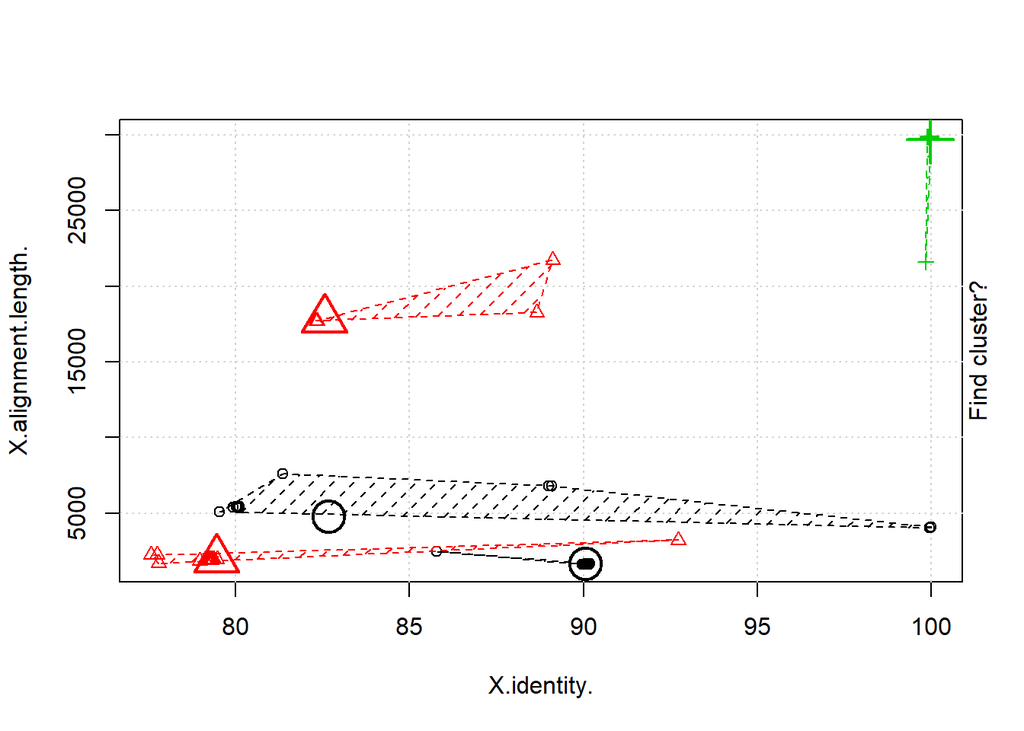

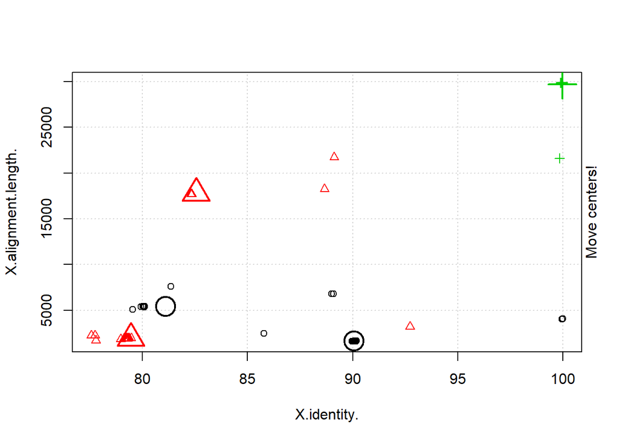

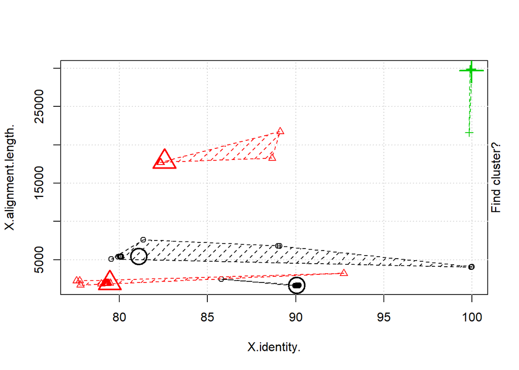

## Fuzzy Clustering

### View Optimal $k$

```r
# Helper function
plot_wss_fuzzy <- function(df, distance.method) {
  cmean_withinerror_fuzzy <- function(k) {
    cluster <- cmeans(df, k, iter.max = 100, dist = distance.method)
    return (cluster$withinerror)
  }

  max_k <-10
  wse <- sapply(2:max_k, cmean_withinerror_fuzzy)
  elbowfuzzy <-data.frame(2:max_k, wse)

  # Plot the graph with ggplot
  ggplot(elbowfuzzy, aes(x = X2.max_k, y = wse)) +
    geom_point() +
    geom_line() +
    scale_x_continuous(breaks = seq(1, 20, by = 1))
}
```

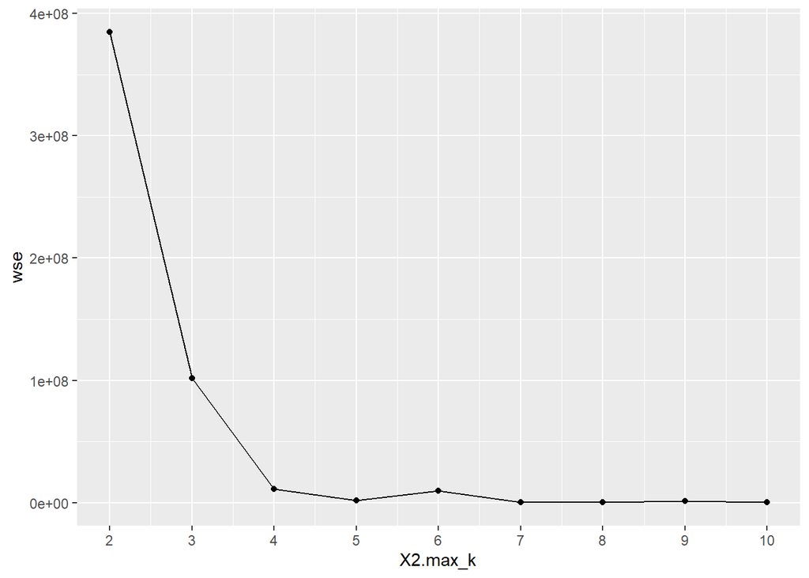

```r
# View optimal K (unscaled dataset) - Euclidean distance
plot_wss_fuzzy(corona, "euclidean")
```

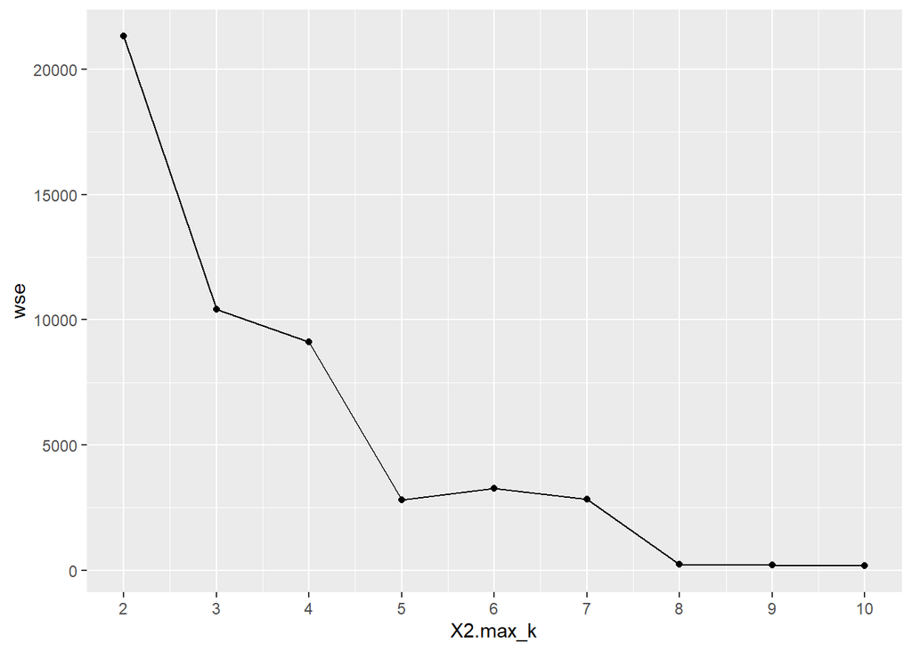

```r
# View optimal K (unscaled dataset) - Manhattan distance
plot_wss_fuzzy(corona, "manhattan")
```

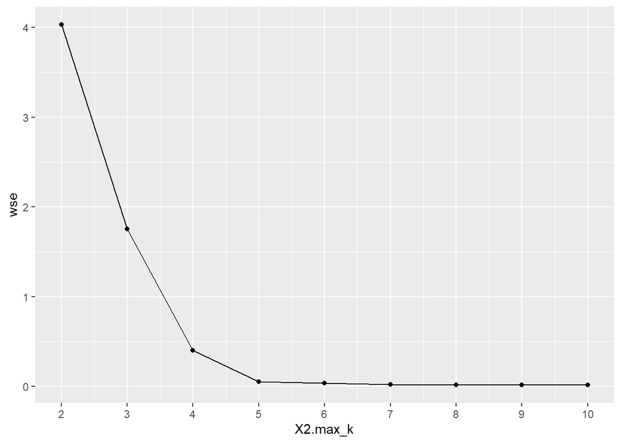

```r
# View optimal K (scaled dataset) - Euclidean distance
plot_wss_fuzzy(corona_scale, "euclidean")
```

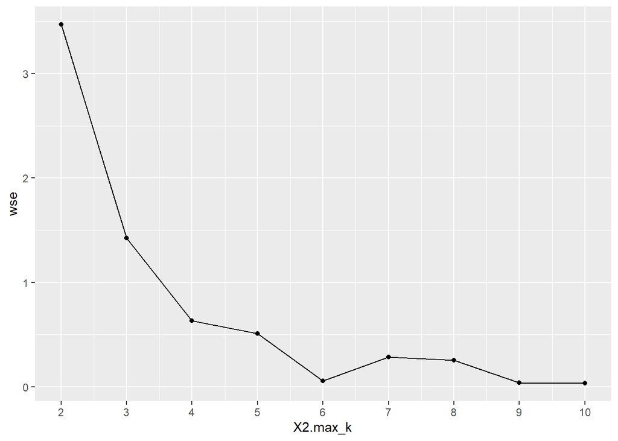

```r
# View optimal K (scaled dataset) - Manhattan distance
plot_wss_fuzzy(corona_scale, "manhattan")
```

### Details of the Fuzzy Clusters

Inspect details for the best Fuzzy clusters, such as cluster labels, centroids and more.

```r
corona_cluster_fuzzy <-cmeans(corona_scale, 5, dist = "euclidean")

# How many samples in each cluster?
corona_cluster_fuzzy$size
```

```
## [1] 45 54 55 56 53
```

```r
# Cluster labels: which cluster does each sample is assigned to?
corona_cluster_fuzzy$cluster
```

```
##   [1] 1 1 1 1 1 1 1 1 1 1 1 1 1 1 1 1 1 1 1 1 1 1 1 1 1 1 1 1 1 1 1 1 1 1 1 1 1
##  [38] 1 1 1 1 1 1 1 1 4 4 3 4 3 4 2 3 5 4 2 3 5 4 2 3 5 4 2 3 5 4 2 3 5 4 2 3 5
##  [75] 4 2 3 5 4 2 3 5 4 2 3 5 4 2 3 5 4 2 3 5 4 2 3 5 4 2 3 5 4 2 3 5 4 2 3 5 2
## [112] 3 5 4 2 3 5 4 2 3 5 4 2 3 5 4 2 3 5 4 2 3 5 4 2 3 5 4 2 3 5 4 2 3 5 4 2 3
## [149] 5 4 2 3 5 4 2 3 5 4 2 3 5 4 2 3 5 4 2 3 5 4 2 3 5 4 2 3 5 4 2 3 5 4 2 3 5
## [186] 4 2 3 5 4 2 3 5 4 2 3 5 4 2 3 5 4 2 3 5 4 2 3 5 4 2 3 5 4 2 3 5 4 2 3 5 4
## [223] 2 3 5 4 2 3 5 4 2 3 5 4 2 3 5 4 2 3 5 4 2 3 5 4 2 3 5 4 2 3 5 4 2 3 5 4 2
## [260] 3 5 4 2
```

```r
clusterlabelscale <- as.data.frame(corona_cluster_fuzzy$cluster)
corona_label <- cbind(corona, clusterlabelscale)

cluster1 <- subset(corona_label, corona_cluster_fuzzy$cluster=='1')
cluster2 <- subset(corona_label, corona_cluster_fuzzy$cluster=='2')
cluster3 <- subset(corona_label, corona_cluster_fuzzy$cluster=='3')
cluster4 <- subset(corona_label, corona_cluster_fuzzy$cluster=='4')
cluster5 <- subset(corona_label, corona_cluster_fuzzy$cluster=='5')
```

Transform the mean values of each numerical attribute (the centroid of each cluster) into data frame.

```r
as.data.frame(colMeans(cluster1[sapply(cluster1, is.numeric)]))
```

```
##                              colMeans(cluster1[sapply(cluster1, is.numeric)])
## X.identity.                                                      9.997533e+01
## X.alignment.length.                                              2.969058e+04
## X.mismatches.                                                    5.755556e+00
## X.gap.opens.                                                     1.111111e-01
## X.q..start.                                                      5.377778e+00
## X.q..end.                                                        2.969496e+04
## X.s..start.                                                      1.022222e+00
## X.s..end.                                                        2.968924e+04
## X.bit.score.                                                     5.478978e+04
## corona_cluster_fuzzy$cluster                                     1.000000e+00
```

```r
as.data.frame(colMeans(cluster2[sapply(cluster2, is.numeric)]))
```

```
##                              colMeans(cluster2[sapply(cluster2, is.numeric)])
## X.identity.                                                         79.454500
## X.alignment.length.                                               1957.407407
## X.mismatches.                                                      359.555556
## X.gap.opens.                                                        33.629630
## X.q..start.                                                         20.944444
## X.q..end.                                                         1957.925926
## X.s..start.                                                          4.759259
## X.s..end.                                                         1941.037037
## X.bit.score.                                                      1367.111111
## corona_cluster_fuzzy$cluster                                         2.000000
```

```r
as.data.frame(colMeans(cluster3[sapply(cluster3, is.numeric)]))
```

```
##                              colMeans(cluster3[sapply(cluster3, is.numeric)])
## X.identity.                                                          82.54822
## X.alignment.length.                                               17798.70909
## X.mismatches.                                                      2918.54545
## X.gap.opens.                                                        164.69091
## X.q..start.                                                        3872.78182
## X.q..end.                                                         21578.96364
## X.s..start.                                                        3785.34545
## X.s..end.                                                         21492.36364
## X.bit.score.                                                      15521.65455
## corona_cluster_fuzzy$cluster                                          3.00000
```

```r
as.data.frame(colMeans(cluster4[sapply(cluster4, is.numeric)]))
```

```
##                              colMeans(cluster4[sapply(cluster4, is.numeric)])
## X.identity.                                                          90.37873
## X.alignment.length.                                                1921.25000
## X.mismatches.                                                       160.50000
## X.gap.opens.                                                         12.37500
## X.q..start.                                                       27896.57143
## X.q..end.                                                         29802.26786
## X.s..start.                                                       27730.92857
## X.s..end.                                                         29646.51786
## X.bit.score.                                                       2534.41071
## corona_cluster_fuzzy$cluster                                          4.00000
```

```r
as.data.frame(colMeans(cluster5[sapply(cluster5, is.numeric)]))
```

```
##                              colMeans(cluster5[sapply(cluster5, is.numeric)])
## X.identity.                                                          80.08094
## X.alignment.length.                                                5447.69811
## X.mismatches.                                                       992.00000
## X.gap.opens.                                                         68.58491
## X.q..start.                                                       22531.71698
## X.q..end.                                                         27933.49057
## X.s..start.                                                       22405.60377
## X.s..end.                                                         27804.66038
## X.bit.score.                                                       3966.60377
## corona_cluster_fuzzy$cluster                                          5.00000
```

### Plot Fuzzy Clustering Result

Visualize clusters for each sample trsnaformed into 2 principal components.

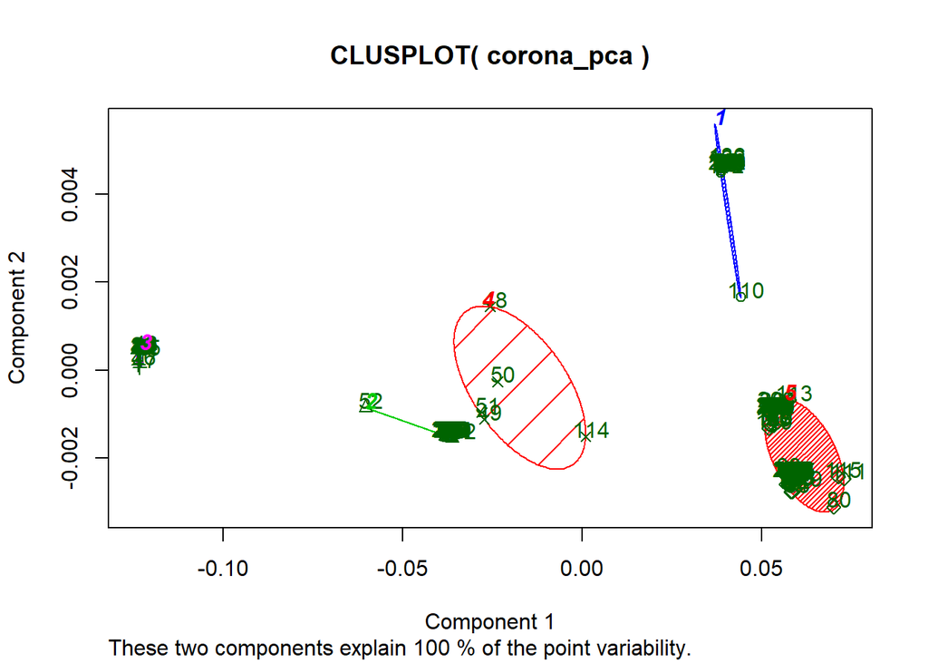